# PA1_template.Rmd

A.Paul

11 Dezember 2016

## Loading and preprocessing the data

# Raw data

Data from website

https://d396qusza40orc.cloudfront.net/repdata%2Fdata%2Factivity.zip

This device collects data at 5 minute intervals through out the day. The data consists of two months of data from an anonymous individual collected during the months of October and November, 2012 and include the number of steps taken in 5 minute intervals each day.

Dataset: Activity monitoring data [52K]

The variables included in this dataset are:

- steps: Number of steps taking in a 5-minute interval (missing values are coded as NA)
- date: The date on which the measurement was taken in YYYY-MM-DD format
- interval: Identifier for the 5-minute interval in which measurement was taken

The dataset is stored in a comma-separated-value (CSV) file and there are a total of 17,568 observations in this dataset.

# Load the data (i.e. read.csv())

The download of the zip-file with the “Activity monitoring data” from the website will doing everytime automatically by the command “download.file()”.

There are three steps to get the dataset: * download the zip-file from the website * unzip and save the csv-file “activity.csv” * read the csv-file and provide the data frame “my_activity”

```r
   ## 1.1 Load the data (i.e. read.csv())
   my_activity <- read_data_activity()
```

# Process/transform the data (if necessary) into a format suitable for your analysis

After reading the dataset there is a function to preprocess and transform the rawdata.

The following steps are doing: * new column “weekday” and “day” are added * sort of the data frame by columns “date” and “interval” * split of the data frame in two new data frames ‘my_act’ without NA values in column “steps” ‘my_act_na’ only with NA values in column “steps” for later preperation

```r
   ## 1.2 Process/transform the data into a format suitable for your analysis
   my_act_list <- preprocessed_data_activity( df = my_activity )
   ## rows without NA values
   my_act <- my_act_list[[1]]
   ## rows only with NA values
   my_act_na <- my_act_list[[2]]

   ## rows without NA values in column "steps"
   str(my_act)
```

```
## 'data.frame':    15264 obs. of  5 variables:
##  $ steps   : int  0 0 0 0 0 0 0 0 0 0 ...
##  $ date    : Factor w/ 61 levels "2012-10-01","2012-10-02",..: 2 2 2 2 2 2 2 2 2 2 ...
##  $ interval: int  0 5 10 15 20 25 30 35 40 45 ...
##  $ weekday : Factor w/ 7 levels "Fri","Mon","Sat",..: 6 6 6 6 6 6 6 6 6 6 ...
##  $ day     : Factor w/ 61 levels "Nov 01","Nov 02",..: 32 32 32 32 32 32 32 32 32 32 ...
```

```r
   lv_obs <- length(my_act$date)
```

There are 15264 observations with values ( not NA’s ) for the column ‘steps’.

## What is mean total number of steps taken per day?

For this part of the assignment, you can ignore the missing values in the dataset. 1. Make a histogram of the total number of steps taken each day

[figure not shown]

```r
## Histogram of the total number of steps taken each day
   plot_hist_per_day( df = my_act, f_screen = TRUE )
```

There are any days (par example 10/11/2012) without observations.

2. Calculate and report the mean and median total number of steps taken per day

```r
## Mean and median number of steps taken each day
   my_mean_median <- get_mean_median_per_day( df = my_act )
## HTML output
   print(my_mean_median, type="html")
```

```
##          date mean_of_steps median_of_steps median_which
## 1  2012-10-02     0.4375000               0            1
## 2  2012-10-03    39.4166667               0            1
## 3  2012-10-04    42.0694444               0            1
## 4  2012-10-05    46.1597222               0            1
## 5  2012-10-06    53.5416667               0            1
## 6  2012-10-07    38.2465278               0            1
## 7  2012-10-09    44.4826389               0            1
## 8  2012-10-10    34.3750000               0            1
## 9  2012-10-11    35.7777778               0            1
## 10 2012-10-12    60.3541667               0            1
## 11 2012-10-13    43.1458333               0            1
## 12 2012-10-14    52.4236111               0            1
## 13 2012-10-15    35.2048611               0            1
## 14 2012-10-16    52.3750000               0            1
```

[output cut: 39 more lines]

## What is the average daily activity pattern?

1. Make a time series plot (i.e. type = “l”) of the 5-minute interval (x-axis) and the average number of steps taken, averaged across all days (y-axis)

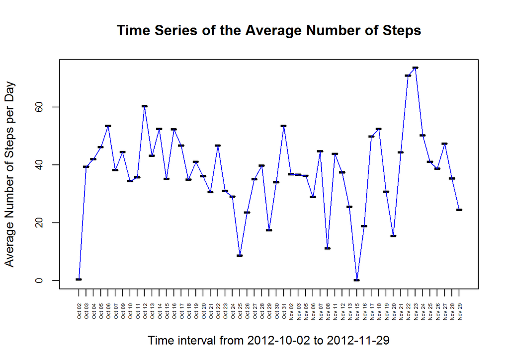

```r
## Time series plot of the average number of steps taken
   plot_time_series_of_steps( df = my_mean_median, f_screen = TRUE )
```

2. Which 5-minute interval, on average across all the days in the dataset, contains the maximum number of steps?

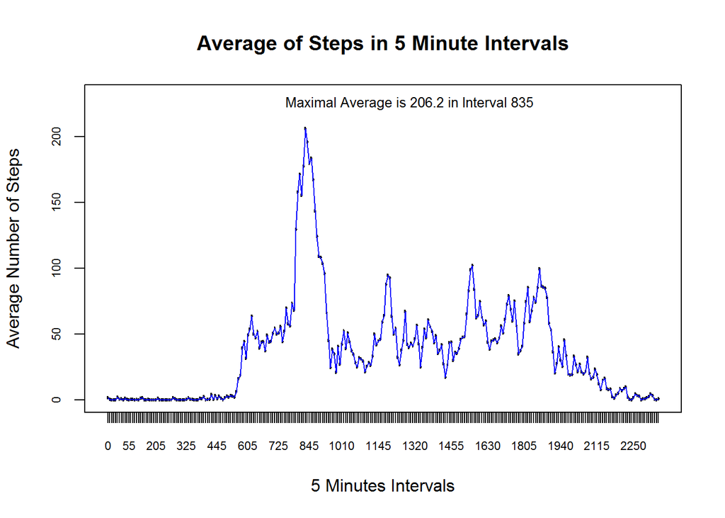

```r
## The 5-minute interval that, on average, contains the maximum number of steps
   plot_time_series_of_steps_per_5min( df = my_act, f_screen = TRUE )
```

## Imputing missing values

Note that there are a number of days/intervals where there are missing values (coded as NA). The presence of missing days may introduce bias into some calculations or summaries of the data.

1. Calculate and report the total number of missing values in the dataset (i.e. the total number of rows with NAs)

```r
  ## in function preprocessed_data_activity( df ) there provide a
  ## data frame 'my_act_na' with only rows NA for 'steps'
  str(my_act_na)
```

```
## 'data.frame':    2304 obs. of  5 variables:
##  $ steps   : int  NA NA NA NA NA NA NA NA NA NA ...
##  $ date    : Factor w/ 61 levels "2012-10-01","2012-10-02",..: 1 1 1 1 1 1 1 1 1 1 ...
##  $ interval: int  0 5 10 15 20 25 30 35 40 45 ...
##  $ weekday : Factor w/ 7 levels "Fri","Mon","Sat",..: 2 2 2 2 2 2 2 2 2 2 ...
##  $ day     : Factor w/ 61 levels "Nov 01","Nov 02",..: 31 31 31 31 31 31 31 31 31 31 ...
```

```r
  lv_obs_na <- length(my_act_na$date)
```

There are 2304 observation with no value ( NA’s ) for the column ‘steps’.

2. Devise a strategy for filling in all of the missing values in the dataset. The strategy does not need to be sophisticated. For example, you could use the mean/median for that day, or the mean for that 5-minute interval, etc.

```r
##--------------------------------------------------------------------------------
## function impute_missing( df, df_na )
## task:
##   - Code to describe and show a strategy for imputing missing data
## arguments
##   - df    data frame without NA value
##   - df_na data frame only with NA values
## return
##   - data frame mit sampled "new" data for "steps"
##
impute_missing <- function( df, df_na ) {

  if ( length(df_na$date) > 0 ) {

    ## define start point
    set.seed(42)

    ## bootstrap sampling per weekday
    l_sample <- sample(x = df$steps, size = length(df_na$steps), replace = FALSE )

    my_df_na <- df_na

    for ( idx in 1:length(my_df_na$steps) ) {
      my_df_na$steps[idx] <- l_sample[idx]
      idx <- idx + 1
    }

    my_data <- rbind( df, my_df_na )

  } else {
    my_data <- df
  }

  my_data

}
```

There are the observation on the weekdays with ready value in the field ‘steps’.

```r
print(table(my_act$weekday), type="html")
```

```
##
##  Fri  Mon  Sat  Sun  Thu  Tue  Wed
## 2016 2016 2016 2016 2304 2592 2304
```

Now the observations on the weekdays with missing values in the field ‘steps’.

```r
print(table(my_act_na$weekday), type="html")
```

```
##
## Fri Mon Sat Sun Thu Tue Wed
## 576 576 288 288 288   0 288
```

On Thesday there is no missing value, so it is ok. And at the others weekdays thers are enough values to take a sample.

After using the R-statement “set.seed(42)” should the reproduciblity of the pseudo numbers be saved.

3. Create a new dataset that is equal to the original dataset but with the missing data filled in.

```r
## Code to describe and show a strategy for imputing missing data
   my_act_impute <- impute_missing_value( df = my_act, df_na = my_act_na )
## attrbutes of the new data frame with missing data filled in
   str(my_act_impute)
```

```
## 'data.frame':    17568 obs. of  6 variables:
##  $ steps     : int  0 0 0 0 0 0 0 0 0 0 ...
##  $ date      : Factor w/ 61 levels "2012-10-01","2012-10-02",..: 1 1 1 1 1 1 1 1 1 1 ...
##  $ interval  : int  0 5 10 25 30 35 40 50 55 110 ...
##  $ weekday   : Factor w/ 7 levels "Fri","Mon","Sat",..: 2 2 2 2 2 2 2 2 2 2 ...
##  $ day       : Factor w/ 61 levels "Nov 01","Nov 02",..: 31 31 31 31 31 31 31 31 31 31 ...
##  $ weekendcat: Factor w/ 2 levels "weekend","weekdays": 1 1 1 1 1 1 1 1 1 1 ...
```

```r
   lv_obs_new <- length(my_act_impute$date)
```

There are 17568 observation after filled in missing value in field ‘steps’.

[figure not shown]

```r
## Histogram of the total number of steps taken each day after
## missing values are imputed
   plot_hist_per_day( df = my_act_impute, f_screen = TRUE )
```

## Are there differences in activity patterns between weekdays and weekends?

For this part the weekdays() function may be of some help here. Use the dataset with the filled-in missing values for this part.

1. Create a new factor variable in the dataset with two levels – “weekday” and “weekend” indicating whether a given date is a weekday or weekend day.

```r
  ## in function
  ## weekday
  ## my_act <- transform( df,
  ##                      weekday = format(as.Date(date), "%a") )

  ## in function impute_missing_value()
  ## weekend / weekday
  ## my_act_impute <- mutate( my_act_impute,
  ##                         weekendcat = factor( my_act_impute$weekday == "Sat" |
  ##                                              my_act_impute$weekday == "Sun",
  ##                                              labels = c("weekend", "weekdays") )
```

2. Make a panel plot containing a time series plot (i.e. type = “l”) of the 5-minute interval (x-axis) and the average number of steps taken, averaged across all weekday days or weekend days (y-axis). The plot should look something like the following, which was created using simulated data:

[figure not shown]

```r
## Panel plot comparing the average number of steps taken
## per 5-minute interval across weekdays and weekends
   plot_compare_ave_number_of_steps( df = my_act_impute, f_screen = TRUE )
```